# An Extremely Short Introduction to Tidyverse

# Introduction

[Tidyverse](https://www.tidyverse.org/) is a collection of packages that makes working with data simpler and more consistent.

A good overview is given in the [RStudio Data Transformation Cheatsheet](https://raw.githubusercontent.com/rstudio/cheatsheets/main/data-transformation.pdf) and an introduction can be found in the [Section on Data Wrangling](https://r4ds.had.co.nz/wrangle-intro.html) the free book [R for Data Science](https://r4ds.had.co.nz).

To use tidyverse you have to install it first with `install.packages("tidyverse")`. Load tidyverse:

```r
library("tidyverse")
```

# Tibbles

A [`tibble`](https://tibble.tidyverse.org/) is a replacement for a `data.frame` that is simpler and often faster.

The iris data comes as a `data.frame`.

```r
data("iris")
head(iris)
```

```
##   Sepal.Length Sepal.Width Petal.Length Petal.Width Species
## 1          5.1         3.5          1.4         0.2  setosa
## 2          4.9         3.0          1.4         0.2  setosa
## 3          4.7         3.2          1.3         0.2  setosa
## 4          4.6         3.1          1.5         0.2  setosa
## 5          5.0         3.6          1.4         0.2  setosa
## 6          5.4         3.9          1.7         0.4  setosa
```

Convert the data into a `tibble`.

```r
iris <- as_tibble(iris)
iris
```

```
## # A tibble: 150 × 5
##    Sepal.Length Sepal.Width Petal.Length Petal.Width Species
##           <dbl>       <dbl>        <dbl>       <dbl> <fct>
##  1          5.1         3.5          1.4         0.2 setosa
##  2          4.9         3            1.4         0.2 setosa
##  3          4.7         3.2          1.3         0.2 setosa
##  4          4.6         3.1          1.5         0.2 setosa
##  5          5           3.6          1.4         0.2 setosa
##  6          5.4         3.9          1.7         0.4 setosa
##  7          4.6         3.4          1.4         0.3 setosa
##  8          5           3.4          1.5         0.2 setosa
##  9          4.4         2.9          1.4         0.2 setosa
## 10          4.9         3.1          1.5         0.1 setosa
## # ℹ 140 more rows
```

tibbles can be used (almost) exactly like data.frames.

# Pipes `%>%`

Pipes let you compose a sequence of function calls in a more readable way. The following two lines do the same.

Standard functional form in R using nested functions:

```r
print(head(iris))
```

```
## # A tibble: 6 × 5
##   Sepal.Length Sepal.Width Petal.Length Petal.Width Species
##          <dbl>       <dbl>        <dbl>       <dbl> <fct>
## 1          5.1         3.5          1.4         0.2 setosa
## 2          4.9         3            1.4         0.2 setosa
## 3          4.7         3.2          1.3         0.2 setosa
## 4          4.6         3.1          1.5         0.2 setosa
## 5          5           3.6          1.4         0.2 setosa
## 6          5.4         3.9          1.7         0.4 setosa
```

Using pipes makes this more readable as a sequence of operations:

```r
iris %>% head() %>% print()
```

```
## # A tibble: 6 × 5
##   Sepal.Length Sepal.Width Petal.Length Petal.Width Species
##          <dbl>       <dbl>        <dbl>       <dbl> <fct>
## 1          5.1         3.5          1.4         0.2 setosa
## 2          4.9         3            1.4         0.2 setosa
## 3          4.7         3.2          1.3         0.2 setosa
## 4          4.6         3.1          1.5         0.2 setosa
## 5          5           3.6          1.4         0.2 setosa
## 6          5.4         3.9          1.7         0.4 setosa
```

The pipe supplies the result of the previous function as the **first argument** to the next function. More information on pipes can be found in the package [magrittr](https://magrittr.tidyverse.org/).

# Data Import with `readr`

Use `read_csv()` (note the `_`). It will guess data types and is faster and more versatile compared to the base R read function.

```r
mlb <- read_csv("https://michael.hahsler.net/SMU/EMIS3309/R/examples/MLB_cleaned.csv",
                col_types = "ccffddd")
mlb
```

```
## # A tibble: 1,034 × 7
##    `First Name` `Last Name` Team  Position     `Height(inches)` `Weight(pounds)`
##    <chr>        <chr>       <fct> <fct>                   <dbl>            <dbl>
##  1 Jeff         Mathis      ANA   Catcher                    72              180
##  2 Mike         Napoli      ANA   Catcher                    72              205
##  3 Jose         Molina      ANA   Catcher                    74              220
##  4 Howie        Kendrick    ANA   First Basem…               70              180
##  5 Kendry       Morales     ANA   First Basem…               73              220
##  6 Casey        Kotchman    ANA   First Basem…               75              210
##  7 Robb         Quinlan     ANA   First Basem…               73              200
##  8 Shea         Hillenbrand ANA   First Basem…               73              211
##  9 Terry        Evans       ANA   Outfielder                 75              200
## 10 Reggie       Willits     ANA   Outfielder                 71              185
## # ℹ 1,024 more rows
## # ℹ 1 more variable: Age <dbl>
```

`col_types` can be used to specify the data type for each column (`c` for character, `f` for factor, `d` for double).

# Data Transformation with `dplyr`

[`dplyr`](https://dplyr.tidyverse.org/) uses pipes to apply a series of functions to data. Functions are similar to SQL’s `SELECT ... FROM ... WHERE ... GROUP BY ... ORDER BY ...` syntax. :

- Start with a table (FROM in SQL).
- Pick variables by their names with `select()` (SELECT in SQL).
- Pick observations by their values using `filter()` (WHERE in SQL).
- Reorder the rows using `arrange()` (ORDER BY in SQL).
- Calculate groups summaries using `group_by()` and `summarize()` (GROUP BY and aggregation function in SELECT of SQL).
- Create new variables with functions of existing variables with `mutate()` (a new column in SELECT in SQL).

Variable names (columns) from the data can be directly used in the functions.

Examples:

```r
iris %>% select(starts_with("Sepal"))
```

```
## # A tibble: 150 × 2
##    Sepal.Length Sepal.Width
##           <dbl>       <dbl>
##  1          5.1         3.5
##  2          4.9         3
##  3          4.7         3.2
##  4          4.6         3.1
##  5          5           3.6
##  6          5.4         3.9
##  7          4.6         3.4
##  8          5           3.4
##  9          4.4         2.9
## 10          4.9         3.1
## # ℹ 140 more rows
```

```r
iris %>% filter(Species == "setosa")
```

```
## # A tibble: 50 × 5
##    Sepal.Length Sepal.Width Petal.Length Petal.Width Species
##           <dbl>       <dbl>        <dbl>       <dbl> <fct>
##  1          5.1         3.5          1.4         0.2 setosa
##  2          4.9         3            1.4         0.2 setosa
##  3          4.7         3.2          1.3         0.2 setosa
##  4          4.6         3.1          1.5         0.2 setosa
##  5          5           3.6          1.4         0.2 setosa
##  6          5.4         3.9          1.7         0.4 setosa
##  7          4.6         3.4          1.4         0.3 setosa
##  8          5           3.4          1.5         0.2 setosa
##  9          4.4         2.9          1.4         0.2 setosa
## 10          4.9         3.1          1.5         0.1 setosa
## # ℹ 40 more rows
```

```r
iris %>% arrange(desc(Sepal.Length))
```

```
## # A tibble: 150 × 5
##    Sepal.Length Sepal.Width Petal.Length Petal.Width Species
##           <dbl>       <dbl>        <dbl>       <dbl> <fct>
##  1          7.9         3.8          6.4         2   virginica
##  2          7.7         3.8          6.7         2.2 virginica
##  3          7.7         2.6          6.9         2.3 virginica
##  4          7.7         2.8          6.7         2   virginica
##  5          7.7         3            6.1         2.3 virginica
##  6          7.6         3            6.6         2.1 virginica
##  7          7.4         2.8          6.1         1.9 virginica
##  8          7.3         2.9          6.3         1.8 virginica
##  9          7.2         3.6          6.1         2.5 virginica
## 10          7.2         3.2          6           1.8 virginica
## # ℹ 140 more rows
```

```r
iris %>% group_by(Species) %>% summarize_all(mean)
```

```
## # A tibble: 3 × 5
##   Species    Sepal.Length Sepal.Width Petal.Length Petal.Width
##   <fct>             <dbl>       <dbl>        <dbl>       <dbl>
## 1 setosa             5.01        3.43         1.46       0.246
## 2 versicolor         5.94        2.77         4.26       1.33
## 3 virginica          6.59        2.97         5.55       2.03
```

```r
iris %>% mutate(Sepal.Length_scaled = drop(scale(Sepal.Length)))
```

```
## # A tibble: 150 × 6
##    Sepal.Length Sepal.Width Petal.Length Petal.Width Species Sepal.Length_scaled
##           <dbl>       <dbl>        <dbl>       <dbl> <fct>                 <dbl>
##  1          5.1         3.5          1.4         0.2 setosa               -0.898
##  2          4.9         3            1.4         0.2 setosa               -1.14
##  3          4.7         3.2          1.3         0.2 setosa               -1.38
##  4          4.6         3.1          1.5         0.2 setosa               -1.50
##  5          5           3.6          1.4         0.2 setosa               -1.02
##  6          5.4         3.9          1.7         0.4 setosa               -0.535
##  7          4.6         3.4          1.4         0.3 setosa               -1.50
##  8          5           3.4          1.5         0.2 setosa               -1.02
##  9          4.4         2.9          1.4         0.2 setosa               -1.74
## 10          4.9         3.1          1.5         0.1 setosa               -1.14
## # ℹ 140 more rows
```

Complete example:

```r
iris %>% filter(Species == "setosa") %>%
  select(starts_with("Sepal")) %>%
  arrange(desc(Sepal.Length)) %>%
  head(3)
```

```
## # A tibble: 3 × 2
##   Sepal.Length Sepal.Width
##          <dbl>       <dbl>
## 1          5.8         4
## 2          5.7         4.4
## 3          5.7         3.8
```

`dplyr` also provides join functions (e.g., `inner_join()`) to merge multiple tables.

# Tidy data with `tidyr`

The iris dataset is in the wide format where each row is a flower and each column contains the values of a measurement.

```r
head(iris)
```

```
## # A tibble: 6 × 5
##   Sepal.Length Sepal.Width Petal.Length Petal.Width Species
##          <dbl>       <dbl>        <dbl>       <dbl> <fct>
## 1          5.1         3.5          1.4         0.2 setosa
## 2          4.9         3            1.4         0.2 setosa
## 3          4.7         3.2          1.3         0.2 setosa
## 4          4.6         3.1          1.5         0.2 setosa
## 5          5           3.6          1.4         0.2 setosa
## 6          5.4         3.9          1.7         0.4 setosa
```

An alternative format is the *“long format.”* Each variable has its own row in this format.

To convert the data into a long format we can use `pivot_longer()`. I first add a column with the row ID to identify a flower.

```r
iris_long <- iris %>%
  rowid_to_column("ID") %>%
  pivot_longer(cols = c("Sepal.Length", "Sepal.Width",
                        "Petal.Length", "Petal.Width"))

iris_long
```

```
## # A tibble: 600 × 4
##       ID Species name         value
##    <int> <fct>   <chr>        <dbl>
##  1     1 setosa  Sepal.Length   5.1
##  2     1 setosa  Sepal.Width    3.5
##  3     1 setosa  Petal.Length   1.4
##  4     1 setosa  Petal.Width    0.2
##  5     2 setosa  Sepal.Length   4.9
##  6     2 setosa  Sepal.Width    3
##  7     2 setosa  Petal.Length   1.4
##  8     2 setosa  Petal.Width    0.2
##  9     3 setosa  Sepal.Length   4.7
## 10     3 setosa  Sepal.Width    3.2
## # ℹ 590 more rows
```

Note that each flower has now multiple rows, one for each variable.

An application is to use a long format with `ggplot2` facets to produce a histogram for each variable organized by species.

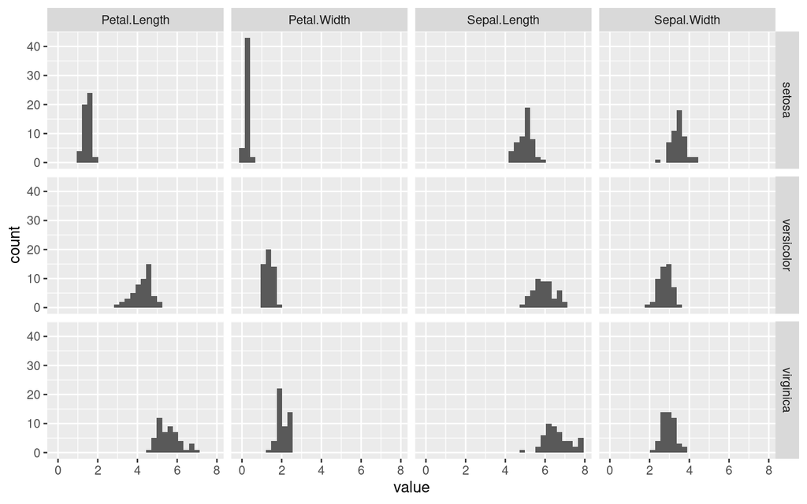

```r
ggplot(iris_long, mapping = aes(value)) +
  geom_histogram() +
  facet_grid(cols = vars(name), rows = vars(Species))
```

Long format can be converted to a wide format using `pivot_wider()`.

# Strings, Dates, Factors, etc.

Tidyverse provides many packages to work with certain data:

- `tidyr` data cleaning and shaping.
- `forcats` Tools for Working with Categorical Variables (Factors).
- `lubridate` Make Dealing with Dates a Little Easier.
- `stringr` A cohesive set of functions designed to make working with strings as easy as possible.
- `purr` Apply functions with tidyverse (functional programming).

The best starting point are the [RStudio Cheatsheets](https://www.rstudio.com/resources/cheatsheets/).